# Asymptotics and Heteroskedasticity

Lecture 5

## Recap

So far, we have discussed (see Lecture 3)

1. Properties of OLS
   - Bias (Mean) - MLR 1-4
   - Efficiency (Variance) - MLR 1-5
   - Distribution - MLR 1-6
2. Simple hypothesis tests
   - $z$-test (know error variance)
   - $t$-test (estimate error variance)

## Recap

Next, we covered (see Lecture 4)

3. Testing linear combinations
   - $t$-test (single equation)
   - $F$-test (multiple equations)
   - Regression significance
4. Testing for structural change
   - Chow test (difference between groups)
   - Dummy interactions

## Exact properties

The properties of OLS from Lecture 3 and Lecture 4 all hold for the **exact** sample

- *exact*: for a given, finite $n$
- also referred to as *finite* or *small* sample properties

**Begs the question:**

- does anything change as $n$ increases?
- what happens in the limit as $n\rightarrow \infty$?

## Asymptotic properties

Today we will discuss the *asymptotic properties* of OLS

- also referred to as **large sample** properties

Noteably,

1. Consistency
2. Asymptotic normality

## CLRM

We will see that as $n$ gets large, we will be able to relax certain assumptions.

1. Replace MLR 4 ($E[u|\mathbf{x}]=0$) with a weaker uncorrelatedness: $E[u\mathbf{x}]=0$
2. Relax MLR 6 ($u|\mathbf{x}\sim N(0,\sigma^2)$) entirely

In the second half of the lecture, we will look at heteroskedasticity

3. Relax MLR 5 ($Var(u|\mathbf{x})=\sigma^2$)

# Consistency

In Lecture 3 we solved for,

$$\hat{\beta}_1 = \beta_1 + \underbrace{\textcolor{red}{\frac{1}{\text{SST}_x}\sum_{i=1}^{n}(x_{i}-\bar{x})}}_{\text{all depends on }X}u_i$$

where,

$$\text{SST}_x=\sum_{i=1}^{n}(x_{i}-\bar{x})^2$$

This was for the *simple linear model*.

We can re-write this as,

$$\hat{\beta}_1 = \beta_1 + \frac{\sum_{i=1}^{n}(x_{i}-\bar{x})u_i}{\sum_{i=1}^{n}(x_{i}-\bar{x})^2} = \beta_1 + \frac{\textcolor{blue}{n^{-1}}\sum_{i=1}^{n}(x_{i}-\bar{x})u_i}{\textcolor{blue}{n^{-1}}\sum_{i=1}^{n}(x_{i}-\bar{x})^2}$$

Then, as $n\rightarrow \infty$

$$\hat{\beta}_1 \rightarrow_p \beta_1 + \frac{Cov(x_i,u_i)}{Var(x_i)}$$

## Probability limit

We say that the probability limit of the OLS estimator is:

$$\text{plim}\; \hat{\beta}_1 = \beta_1 + \frac{Cov(x_i,u_i)}{Var(x_i)}$$

So long as,

$$Var(x_i) \neq 0$$

Which is true under MLR 3 (eqiv. SLR 3).

## Proof

**Why?** This is an application of the **Weak Law of Large Numbers**.<sup>1</sup>

Which holds, so long as the terms have a finite variance.

- $Var(x_i)<\infty$
- $Var(u_i)<\infty$

**Weak Law of Large Numbers**

The WLLN states that the sample mean converges in probability to the expected value of a random variable under iid sampling:

$$\bar{x}_n = n^{-1}\sum_{i=1}^n x_i \rightarrow_p E[x_i]$$
as $n\rightarrow \infty$. We typically assume that the variable has a finite variance; though, it is not strictly necessary.

[^1]: It also makes use of Slutzky’s theorem which states that if $X_n\rightarrow_p X$ and $Y_n\rightarrow_p Y$, then $X_n/Y_n\rightarrow_p X/Y$; so long as $Y\neq 0$.

So,

$$n^{-1}\sum_{i=1}^{n}(x_{i}-\bar{x})u_i \rightarrow_p Cov(x_i,u_i)$$

and,

$$n^{-1}\sum_{i=1}^{n}(x_{i}-\bar{x})^2 \rightarrow_p Var(x_i)$$

And by Slutzky’s theorem, the ratio of the two terms converges in probability too.

Assuming $Cov(x_i,u_i)=0$ (*weaker than* MLR 4)

$$\text{plim}\; \hat{\beta}_1 = \beta_1$$

$\rightarrow$ the OLS estimator is **consistent**.

## Consistency

So, under MLR 1-3 PLUS<sup>1</sup>

> **MLR-4a: Zero mean and Zero Correlation**

> $E[u]=0$ and $E[ux_{j}]=0$ for $j=1,\dots,k$.

OLS is consistent.

**Important**

Consistent is not the same as unbiased. Unbiasedness is a property for an exact $n$, while constistency concerns the probability limit of the estimator as $n\rightarrow \infty$. Estimators can be consistent, but biased. In some instances, estimators can be unbiased but not consistent because their variances do not shrink as $n$ increases.

[^2]: Here I use the label MLR 4a (‘a’ for alternative). Wooldridge uses 4’, which can get lost in notation. Both are acceptable.

## MLR 4 vs MLR 4a

**What is difference?** Under MLR 4, the population regression function is correctly specified

$$E[y_i|\mathbf{x}] = \beta_0 + \beta_1x_{i1} + \dots + \beta_kx_{ik}$$

Under MLR 4a this need not hold.

- the model may be missing some non-linear functions of $x_j$: terms in $x_j^2$, $x_j^3$, etc.
- the model may be missing interactions of regressors.

## Simulation

We can demonstrate consistency by showing that as $n$ increases, the variance of the estimator collapses around the true value.

```
Mean of slope estimates:
```

```
  n=50  n=100  n=200  n=400  n=800 n=1600 n=3200 n=6400
0.4915 0.4984 0.4933 0.4892 0.5026 0.5034 0.4997 0.4981
```

```
SD of slope estimates:
```

```
  n=50  n=100  n=200  n=400  n=800 n=1600 n=3200 n=6400
0.4888 0.3646 0.2409 0.1633 0.1198 0.0886 0.0599 0.0419
```

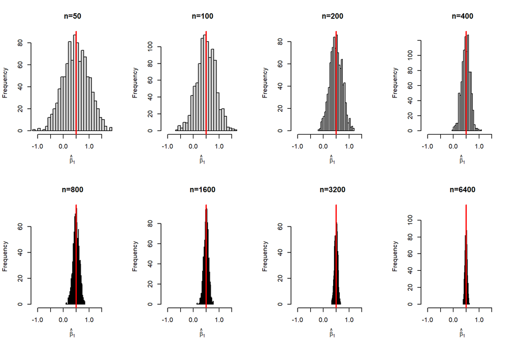

## Multivariate case

Is anything different in the multivariate case? **No**

We know that we can define the OLS estimator for $\beta_1$ from,

$$y_i = \beta_0 + \beta_1 x_{i1} + \dots + \beta_kx_{ik} + u_i$$

As a simple linear regression of residualized variables $\tilde y$ and $\tilde x$:

$$\tilde y_i = \beta_0 + \beta_1 \tilde x_{i1} + v_i$$

So,

$$\text{plim}\; \hat{\beta}_1 = \beta_1 + \frac{Cov(x_{i1}^*,u_i)}{Var(x_{i1}^*)}$$

where $x_{i1}^* = \text{plim}\; \tilde x_{i1}$.

Under, MLR 4a

$$Cov(x_{i1}^*,u_i) = 0$$

since $x_{i1}^*$ is just a linear function of $x_{i1},\dots,x_{ik}$; all of which are uncorrelated with $u_i$.

# Asymptotic Normality

## Result

$$\sqrt{n} (\hat{\beta}_j - \beta_j) \rightarrow_d N\big(0,Var(\hat{\beta}_j)\big)$$

where,

$$Var(\hat\beta_j) = \text{plim}\;\frac{\sigma^2}{n^{-1}SSR_j}$$

**Note**

This formula for limiting variance has an $n^{-1}$ in the denominator that doesn’t appear in the exact sample formula for the conditional variance. Wooldridge (2025, 174) includes the formula:

$$n^{-1}SSR_j = n^{-1}\sum_{i=1}^n\hat{r}_{ij}^2$$

where $\hat{r}_{ij}$ is the residual from a regression of $x_j$ on all other regressors; *including a constant*.

**Why this strange form?** With the $\sqrt{n}$.

1. $\hat{\beta_j} \rightarrow_p \beta_j$
2. In the limit, the estimator has no distribution (variance=0); degenerate
3. The speed of convergence is $n^{-1/2}$<sup>1</sup>
4. If we scale the estimator (minus it’s limit ($\beta_j$)) we end up with a non-degenerate distribution
5. This is why SEs of estimator shrinks at roughly $n^{-1/2}$: if you quadruple the sample size, the SE halves.

BUT, if you de-mean $\hat\beta_j$ and scale by $\sqrt{n}$, the term converges to a stable, **normal** distribution.

[^3]: We say OLS is $\sqrt{n}$-consistent (or “root-$n$” consistent)

## Proof

The result is a direct application of the **Central Limit Theorem**

- $\sqrt{n}$ (root-$n$) is the scaling applied to a series of random variables to make them converge to a normal distribution.

**Central Limit Theorem**

CLT states that given a **sequence** of iid random variables $x_1,x_2,...,x_n$, such $E[x_j]=0$ and $Var(x_j)=\sigma^2<\infty$.

$$\sqrt{n}\bar{x}_n = n^{-1/2}\sum_{i=1}^nx_i \rightarrow_d N(0,\sigma^2)$$

as $n\rightarrow \infty$.

## Standardization

The result can be standardized,

$$\begin{aligned}
\frac{\textcolor{blue}{\sqrt{n}}(\hat{\beta}_j - \beta_j)}{\sqrt{\sigma^2/(\textcolor{red}{n^{-1}} SSR_j)}} &= \frac{\textcolor{blue}{\sqrt{n}}(\hat{\beta}_j - \beta_j)}{\textcolor{red}{\sqrt{n}}\sqrt{\sigma^2/ SSR_j}} \\
&= \frac{(\hat{\beta}_j - \beta_j)}{sd(\hat\beta_j)} \\
&\rightarrow_d N(0,1)
\end{aligned}$$

Under MLR 1-5; **even without MLR 6**

## Approximate distribution

We say that,

$$\frac{(\hat{\beta}_j - \beta_j)}{sd(\hat\beta_j)} \overset{a}{\sim} N(0,1)$$

where $\overset{a}{\sim}$ means “approximately distributed”.

- for a large enough $n$, it does not matter that you do not know the distribution of $u|\mathbf{x}$.

## Estimated variance

Likewise,

$$\frac{(\hat{\beta}_j - \beta_j)}{se(\hat\beta_j)} \rightarrow_d N(0,1)$$

where $se(\hat\beta_j) = \sqrt{\hat\sigma^2/SSR_j}$

- for a large enough $n$, it does not matter that you do not know $\sigma^2$ either.

## $t$-distribution

As was suggested in Lecture 3,

$$t_{n-k-1}\rightarrow N(0,1)\quad \text{as}\quad n\rightarrow \infty$$

BUT remember

- $t$ distribution result relies on MLR 1-6.
- MLR 1-5 gives you normality, by CLT.

## $F$-distribution

Also under MLR 1-6, we had a range of tests that had a $F$ distribution (see Lecture-4)

$$F_{q,n-k-1}\rightarrow \chi^2_q/q\quad \text{as}\quad n\rightarrow \infty$$

As above,

- $F$ distribution of linear tests relies on MLR 1-6.
- MLR 1-5 gives you chi-squared, by CLT.
- Notice, $q\times F_{q,n-k-1}\rightarrow \chi^2_q\quad \text{as}\quad n\rightarrow \infty$

## Hypothesis tests

Having said that, it is equally accurate to say

$$t\text{-stat} \overset{a}{\sim}t_{n-k-1}$$

and

$$F\text{-stat} \overset{a}{\sim}F_{q,n-k-1}$$

**without MLR 6**.

- Likewise for Chow test.

## Demonstration

Let’s simulate a model:

$$y_i = 2 + 0.5x_i + u_i$$

where,

$$u_i+1|x_i \sim \text{Exp} (1)$$

- $\Rightarrow E[u_i|x_i = 0]$
- $\Rightarrow Var(u_i|x_i) = 1$
- BUT the error has a **skewness** factor of 2.

## Simulation

Here we plot the standardized coefficients.

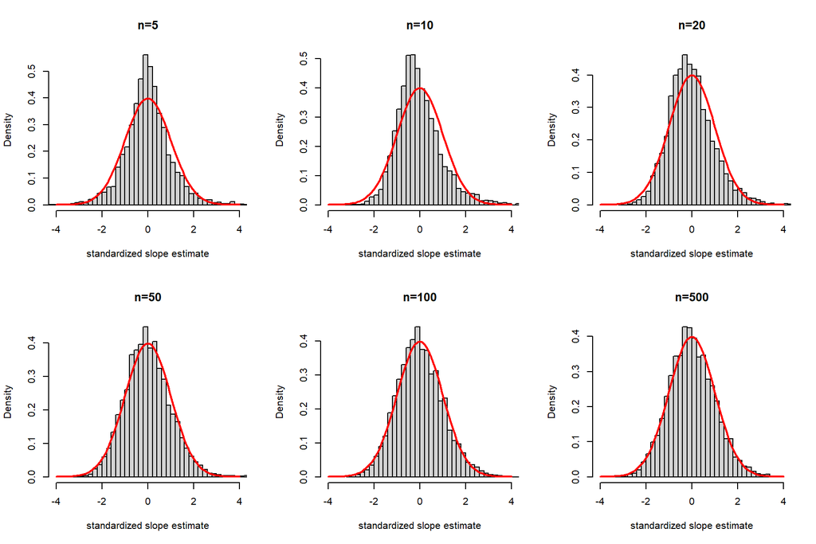

# Asymptotic Tests

## The Lagrange Multiplier (LM) statistic

**Note**

We are covering this because it is relevant to tests for Heteroskedasticity (Ch. 8.3).

The $LM$-stat can be used under MLR 1-5 (therefore MLR 6 is not needed).

$$y_i = \beta_0 + \beta_1x_{i1} + \dots + \beta_{k-q}x_{i,k-q} + \textcolor{blue}{\beta_{k-q+1}}x_{i,k-q+1} + \dots + \textcolor{blue}{\beta_k}x_{ik}+u_i$$

Suppose, you want to test

$$H_0: \textcolor{blue}{\beta_{k-q+1}}=0,\dots,\textcolor{blue}{\beta_k}=0$$

- The last q parameters are all 0.
- We saw a version of this for the $F$-test

## $LM$-stat

You can compute the $LM$-stat as follows:

1. estimate the **restricted** model

$$y_i = \tilde\beta_0 + \tilde\beta_1x_{i1}+\dots+\tilde\beta_{k-q}x_{i,k-q} + \tilde u_i$$

where $\tilde u_i$ is the residual from this restricted-model regression.

2. regress $\tilde u_i$ on $x_1,\dots,x_k$ (all $k$ regressors)
   - intuitively none of the regressors should be significant under the $H_0$
3. store the $\mathbf{R}_{\tilde u}^2$ from this *auxilliary* regression
4. construct the $LM$-stat

$$LM\text{-stat} = n\times \mathbf{R}_{\tilde u}^2$$

5. Under the null (and assuming MLR 1-5): $LM\text{-stat}\rightarrow_d \chi^2_q$
6. Compute $p$-value or use critical value to form rejection rule.

## Recap

1. We can relax MLR 4
   - Under MLR 4a OLS is consistent, but potentially biased in the finite sample<sup>1</sup>
2. We can drop MLR 6
   - Regardless the true (conditional) distribution of $u_i$, the OLS estimator will be approximately normal for $n$ large
   - Conduct inference based on standard normal and chi-squared distributions.
   - Tests using $t$/$F$ distribution remain slightly more conservative if distribution is unknown.
   - $LM$ test option
3. OLS is asymptotically efficient under Gauss-Markov assumptions (MLR 1-5) (read Wooldridge 2025, ch. 5.3)
[^4]: Recall from Lecture 3, unbiasedness requires MLR 4.

# Heteroskedasticity

## MLR #5

> **MLR-5: Homoskedasticity**

> The variance of the error term is the same given any value of $\mathbf{x}$.

> $$Var(u|\mathbf{x}) = \sigma^2$$
- States the error variance is the same constant, independent of $\mathbf{x}$

**What if this is NOT true?**

## Heteroskedasticity

A heteroskedastic error variance can be denoted:

$$Var(u_i|\mathbf{x}_i) = \sigma^2_i$$

- the $i$ shows that the variance depends on $i$ (or the value of $\mathbf{x}_i$)<sup>1</sup>
- implies that the sampling error is NOT iid (independently and *identically* distributed)
[^5]: Wooldridge (2025, 278) states “variance of the error depends upon the particular value of $x_i$”. This is one form of heteroskedasticity; e.g. $\sigma^2_i = \sigma^2x_i$. But heteroskedasticity can be more general than this.

## Example

Years of education (modelled here with quadratic term in `edu`; using MORG 2024).

[figure not shown]

## Implications

From Lecture 3, for the *simple linear regression* case,

$$Var(\hat{\beta}_1|X) = E\Bigg[\bigg(\frac{1}{\text{SST}_x}\sum_{i=1}^{n}(x_{i}-\bar{x})u_i\bigg)^2\Bigg|X\Bigg]$$

To get the result from Lecture 3 we used MLR 5, **which no longer holds**.

## Variance

$$Var(\hat{\beta}_1|X) = \frac{\sum_{i=1}^{n}(x_{i}-\bar{x})^2E[u_i^2|X]}{\text{SST}_x^2}=\frac{\sum_{i=1}^{n}(x_{i}-\bar{x})^2\textcolor{red}{\sigma_i^2}}{\text{SST}_x^2}$$

The formula is very similar to what you have under homoskedasticity,

$$Var(\hat{\beta}_1|X) = \frac{\sum_{i=1}^{n}(x_{i}-\bar{x})^2\textcolor{blue}{\sigma^2}}{\text{SST}_x^2}=\frac{\textcolor{blue}{\sigma^2}}{\text{SST}_x}$$

except it cannot be simplified, because $\textcolor{red}{\sigma^2_i}$ depends on $i$.

## Estimator

The most intuitive estimator for the variance is given by,

$$\widehat{Var}(\hat{\beta}_1|X) = \frac{\sum_{i=1}^{n}(x_{i}-\bar{x})^2\hat{u}_i^2}{\text{SST}_x^2}$$

as it replaces the error term with the estimated residual.

- Referred to as the White (1980) estimator.
- The estimator has the appropriate asymptotic limit.

## Multivariate case

In the multivariate case,

$$y_i = \beta_0 + \beta_1 x_{i1} + \beta_2 x_{i2} + \dots + \beta_k x_{ik} + u_i$$

we had that under **homoskedasticity**,

$$Var(\hat{\beta}_j|X) = \frac{\sigma^2}{\text{SSR}_j}$$
- where $SSR_j$ is from a regression of regressor $x_j$ on all other regressors.

Under **heteroskedasticity**, we

$$Var(\hat{\beta}_j|X) = \frac{\sum_{i=1}^{n}(\tilde x_{ij}-\bar{\tilde x}_j)^2\sigma_i^2}{\text{SSR}_j^2}$$

where $\tilde x_{ij}$ is the residual from the regression of $x_j$ on all other regressors.

## Estimator

The following formula appears in Wooldridge (2025, 279) for the estimator:

$$\widehat{Var}(\hat{\beta}_j|X) = \frac{\sum_{i=1}^{n}\hat{r}_{ij}^2\hat{u}_i^2}{\text{SSR}_j^2}$$

- $\hat{r}_{ij}$ is the residual from a regression of $x_j$ on all other regressors **as well as a constant**.
  - $\sum_{i=1}^n\hat{r}_{ij}=0$: the mean of the residual is zero
  - $(\tilde x_{ij}-\bar{\tilde x}_j)^2$ is replaced with $\hat{r}_{ij}^2$

## HC’s

Note: this is not the only **heteroskedastic-consistent** (HC) SE estimator.<sup>1</sup>

## Consequences

1. Does heteroskedasticity make OLS biased?
   - **No!** (Un)biasedness depends on MLR 1-4
   - the estimation of heteroskedastic-robust SEs has no bearing on the estimated OLS coefficients.
   - heteroskedasticity *may* be the result of omitted variables and/or model mis-specification.
2. Does it make it less efficient?
   - **Yes**. Under heteroskedasticity, OLS is no longer BLUE
   - See Weighted Least Squares Estimation (Ch. 8.4, not examinable)
3. $t$ tests
   - exact distribution of $t$-stats is not $t$ distributed
   - the asymptotic distributions remain normal
   - can use $t$ distributions as an approximation for larger $n$ (slightly more conservative)
4. $F$ tests
   - there is a heteroskedastic-robust $F$-stat (also referred to Wald Statistic)
   - Chow test is not valid, but can use dummy variable interaction method with robust $F$ test.
   - Can use heteroskedasticity-robust LM test method

## Example: MORG (2024)

- Stata
- R

```stata
* Use the vce() option with robust
reg lnwage edu exp expsq female unioncov, vce(robust)

* You can also just say,
* reg lnwage edu exp expsq female unioncov, robust
```

```
Linear regression                               Number of obs     =      8,955
                                                F(5, 8949)        =     549.77
                                                Prob > F          =     0.0000
                                                R-squared         =     0.2822
                                                Root MSE          =     .52055

------------------------------------------------------------------------------
             |               Robust
      lnwage | Coefficient  std. err.      t    P>|t|     [95% conf. interval]
-------------+----------------------------------------------------------------
         edu |    .112617   .0023257    48.42   0.000     .1080581    .1171759
         exp |   .0219653   .0013864    15.84   0.000     .0192476     .024683
       expsq |  -.0003148   .0000284   -11.07   0.000    -.0003706   -.0002591
      female |  -.2026692   .0111009   -18.26   0.000    -.2244295    -.180909
    unioncov |   .1091537   .0407743     2.68   0.007     .0292268    .1890807
       _cons |   1.380385     .08791    15.70   0.000     1.208061    1.552708
------------------------------------------------------------------------------
```

```r
# Load the Stata file
morg_data <- read_dta(file.path(data_dir, "morg24_all.dta"))

# Packages
library(sandwich)
library(lmtest)

# Estimate bivariate linear regression
model <- lm(lnwage ~ edu + exp + expsq + female + unioncov, data=morg_data)

# Compute HC1 robust SEs
vce = vcovHC(model, type="HC1")

# Display
coeftest(model, vcov = vce)
```

```
t test of coefficients:

               Estimate  Std. Error t value  Pr(>|t|)
(Intercept)  1.3804e+00  8.7910e-02  15.702 < 2.2e-16 ***
edu          1.1262e-01  2.3257e-03  48.423 < 2.2e-16 ***
exp          2.1965e-02  1.3864e-03  15.843 < 2.2e-16 ***
expsq       -3.1483e-04  2.8434e-05 -11.072 < 2.2e-16 ***
female      -2.0267e-01  1.1101e-02 -18.257 < 2.2e-16 ***
unioncov     1.0915e-01  4.0774e-02   2.677  0.007441 **
---
Signif. codes:  0 '***' 0.001 '**' 0.01 '*' 0.05 '.' 0.1 ' ' 1
```

```r
# Or do this in one step
#coeftest(model, vcov = vcovHC(model, type="HC1"))
```

## Robust SEs

Are heteroskedastic-robust SEs bigger? **Not necessarily**.

- In practice, they can return smaller SEs.
- Implications for power of the test are therefore ambiguous

```stata
* Use the vce() option with robust
est clear
qui reg lnwage edu exp expsq female unioncov
est store Homoskedastic

qui reg lnwage edu exp expsq female unioncov, vce(robust)
est store HC1_Robust

etable, est(Homoskedastic HC1_Robust) column(estimates) novarlabel cstat(_r_b, nformat(%5.4f)) cstat(_r_se, nformat(%5.4f))
```

```
                       Homoskedastic HC1_Robust
-----------------------------------------------
edu                           0.1126     0.1126
                            (0.0021)   (0.0023)
exp                           0.0220     0.0220
                            (0.0014)   (0.0014)
expsq                        -0.0003    -0.0003
                            (0.0000)   (0.0000)
female                       -0.2027    -0.2027
                            (0.0111)   (0.0111)
unioncov                      0.1092     0.1092
                            (0.0473)   (0.0408)
_cons                         1.3804     1.3804
                            (0.0997)   (0.0879)
Number of observations          8955       8955
-----------------------------------------------
```

## Why bother?

Why bother with homoskedastic errors?

- if the error variance is homoskedastic **and normally distributed** then the exact distribution of $t$-stat ($F$-stat) is known for **small sample**.
- no need to use asymptotic approximation
- heteroskedastic-robust SEs (and $t$-stats) are only valid for larger sample sizes.

## Test for heterskedasticity

Can we test whether the data exhibits heteroskedasticity? **Yes**

1. Breusch Pragan test
2. White test (read about this in Ch. 8.3)

## Breusch-Pagan test

$$H_0: Var(u|\mathbf{x}) = \sigma^2$$
Which implies,

$$H_0: E(u^2|\mathbf{x}) = \sigma^2$$

- We are testing whether the conditional expectation function of $u^2$ is independent of $\mathbf{x}$.

For a random sample, if<sup>1</sup>

$$u^2_i = \delta_0 + \delta_1 x_{i1} + \delta_2 x_{i2} + \dots + \delta_k x_{ik} + \nu_i$$

Then the null is:

$$H_0: \delta_1 = \delta_2 = \dots = \delta_k=0$$

- These are multiple linear hypotheses
[^7]: The White test allows for higher order polynomials of $x$’s and interactions, which reflects the fact that we do not the know the exact form of the CEF.

We can test this using a $F$-test of the above regression.

- **However**, we do not observe $u_i^2$.
- Replace with $\hat u_i^2$
- Regress:

$$\hat{u}^2_i = \delta_0 + \delta_1 x_{i1} + \delta_2 x_{i2} + \dots + \delta_k x_{ik} + v_i$$

- Compute $F$-stat or $LM$-stat<sup>1</sup>

$$F\text{-stat} = \frac{\mathbf{R}^2_{\hat{u}^2}/k}{(1-\mathbf{R}^2_{\hat{u}^2})/(n-k-1)} \quad \text{or}\quad LM\text{-stat}=n\times \mathbf{R}_{\hat u^2}^2$$

[^8]: The name Breusch Pragan test is usually reserved for the LM test equivalent where the test-statistic is $LM = n\times\mathbf{R}^2_{\hat{u}^2}$.

## Example: MORG (2024)

- Stata
- R

Breusch-Pagan test ($F$-stat)

```stata
* Use the vce() option with robust
qui reg lnwage edu exp expsq female unioncov

* F-statistic
estat hettest, rhs fstat

* The default test (i.e. without rhs) tests for more general forms of heteroskedasticity.
```

```
Breusch–Pagan/Cook–Weisberg test for heteroskedasticity
Assumption: i.i.d. error terms
Variables: All independent variables

H0: Constant variance

F(5, 8949) =  59.01
  Prob > F = 0.0000
```

Breusch-Pagan test ($LM$-stat)

```stata
* LM-statistic
estat hettest, rhs
```

```
Breusch–Pagan/Cook–Weisberg test for heteroskedasticity
Assumption: Normal error terms
Variables: All independent variables

H0: Constant variance

    chi2(5) = 573.26
Prob > chi2 = 0.0000
```

White test ($LM$-stat)

```stata
* White test
estat imtest, white
```

```
White's test
H0: Homoskedasticity
Ha: Unrestricted heteroskedasticity

   chi2(17) = 402.96
Prob > chi2 = 0.0000

Cameron & Trivedi's decomposition of IM-test

--------------------------------------------------
              Source |       chi2     df         p
---------------------+----------------------------
  Heteroskedasticity |     402.96     17    0.0000
            Skewness |     193.57      5    0.0000
            Kurtosis |     168.45      1    0.0000
---------------------+----------------------------
               Total |     764.97     23    0.0000
--------------------------------------------------
```

In R, the relevant tests are a part of the `lmtest` package.

Breusch-Pagan test ($F$-stat) - can’t find matching R version.

```r
# 1. Extract squared residuals and run auxiliary regression
aux_model <- lm(I(residuals(model)^2) ~ edu + exp + expsq + female + unioncov, data=model.frame(model))

# 2. View F-statistic, degrees of freedom, and p-value
summary(aux_model)
```

```
Call:
lm(formula = I(residuals(model)^2) ~ edu + exp + expsq + female +
    unioncov, data = model.frame(model))

Residuals:
    Min      1Q  Median      3Q     Max
-0.5714 -0.2351 -0.1395  0.0176  5.4707

Coefficients:
              Estimate Std. Error t value Pr(>|t|)
(Intercept) -3.794e-01  1.022e-01  -3.711 0.000208 ***
edu          3.171e-02  2.125e-03  14.921  < 2e-16 ***
exp          5.373e-03  1.455e-03   3.692 0.000224 ***
expsq       -3.406e-05  2.857e-05  -1.192 0.233250
female      -6.764e-02  1.140e-02  -5.933 3.08e-09 ***
unioncov     6.575e-02  4.848e-02   1.356 0.175062
---
Signif. codes:  0 '***' 0.001 '**' 0.01 '*' 0.05 '.' 0.1 ' ' 1

Residual standard error: 0.5338 on 8949 degrees of freedom
Multiple R-squared:  0.03192,   Adjusted R-squared:  0.03138
F-statistic: 59.01 on 5 and 8949 DF,  p-value: < 2.2e-16
```

Breusch-Pagan test ($LM$-stat)

```r
# Using lmtest package
bptest(model, studentize = FALSE)
```

```
    Breusch-Pagan test

data:  model
BP = 573.26, df = 5, p-value < 2.2e-16
```

```r
# Using olsrr package
#library(olsrr)       # Not available in AppsAnywhere
#ols_test_breusch_pagan(model, rhs=TRUE)

# Using skedastic package
#library(skedastic)   # Not available in AppsAnywhere
#breusch_pagan(model, koenker = FALSE)
```

White test ($LM$-stat)

```r
# LM-statistic: e.g.
library(skedastic)    # Not available in AppsAnywhere
white(model, interactions = TRUE)
```

```
# A tibble: 1 × 5
  statistic  p.value parameter method       alternative
      <dbl>    <dbl>     <dbl> <chr>        <chr>
1      403. 4.97e-73        20 White's Test greater
```

# Wrap up

## Weeks 1-5

1. The linear model: MLR 1-6 assumptions, Interpretation
2. OLS: mechanics of “fitting data”
3. Properties of OLS: mean, variance, efficiency, distribution
4. Inference: simple, linear, multiple linear
5. Asymptotics: large sample, relaxing MLR 4 and 6
6. Heteroskedasiticity: relaxing MLR 5

## Next up

1. Causation, selection, randomization
2. Controlling for confounding factors
3. Instrumenting endogenous variables
4. Learning from repeated observations
5. Difference-in-differences

**You have survived the Statistics, now on to the (Applied) Econometrics.**

# References

## Bibliography

Wooldridge, Jeffrey M. 2025. “Introductory Econometrics: A Modern Approach.”